# Risk Factor Analysis

## Outcome Variable

**Outcome Variable:** wast_rec90d

## Predictor Variables

**Intervention Variable:** vagbrth

**Adjustment Set:**

- arm
- sex
- W_mage
- meducyrs
- feducyrs
- hhwealth_quart
- W_mhtcm
- W_nrooms
- brthmon
- W_parity
- impfloor
- impsan
- safeh20
- delta_W_mage
- delta_meducyrs
- delta_feducyrs
- delta_hhwealth_quart
- delta_W_mhtcm
- delta_W_nrooms
- delta_brthmon
- delta_W_parity
- delta_impfloor
- delta_impsan
- delta_safeh20

## Stratifying Variables

The analysis was stratified on these variable(s):

- agecat
- studyid
- country

## Data Summary

| agecat | studyid | country | vagbrth | wast_rec90d | n_cell | n |
| --- | --- | --- | --- | --- | --- | --- |
| 0-24 months | ki1000108-CMC-V-BCS-2002 | INDIA | 0 | 0 | 11 | 326 |
| 0-24 months | ki1000108-CMC-V-BCS-2002 | INDIA | 0 | 1 | 9 | 326 |
| 0-24 months | ki1000108-CMC-V-BCS-2002 | INDIA | 1 | 0 | 109 | 326 |
| 0-24 months | ki1000108-CMC-V-BCS-2002 | INDIA | 1 | 1 | 197 | 326 |
| 0-24 months | ki1000108-IRC | INDIA | 0 | 0 | 24 | 395 |
| 0-24 months | ki1000108-IRC | INDIA | 0 | 1 | 39 | 395 |
| 0-24 months | ki1000108-IRC | INDIA | 1 | 0 | 138 | 395 |
| 0-24 months | ki1000108-IRC | INDIA | 1 | 1 | 194 | 395 |
| 0-24 months | ki1017093b-PROVIDE | BANGLADESH | 0 | 0 | 26 | 307 |
| 0-24 months | ki1017093b-PROVIDE | BANGLADESH | 0 | 1 | 43 | 307 |
| 0-24 months | ki1017093b-PROVIDE | BANGLADESH | 1 | 0 | 102 | 307 |
| 0-24 months | ki1017093b-PROVIDE | BANGLADESH | 1 | 1 | 136 | 307 |
| 0-24 months | ki1017093c-NIH-Crypto | BANGLADESH | 0 | 0 | 18 | 190 |
| 0-24 months | ki1017093c-NIH-Crypto | BANGLADESH | 0 | 1 | 43 | 190 |
| 0-24 months | ki1017093c-NIH-Crypto | BANGLADESH | 1 | 0 | 58 | 190 |
| 0-24 months | ki1017093c-NIH-Crypto | BANGLADESH | 1 | 1 | 71 | 190 |
| 0-24 months | ki1066203-TanzaniaChild2 | TANZANIA, UNITED REPUBLIC OF | 0 | 0 | 24 | 705 |
| 0-24 months | ki1066203-TanzaniaChild2 | TANZANIA, UNITED REPUBLIC OF | 0 | 1 | 32 | 705 |
| 0-24 months | ki1066203-TanzaniaChild2 | TANZANIA, UNITED REPUBLIC OF | 1 | 0 | 240 | 705 |
| 0-24 months | ki1066203-TanzaniaChild2 | TANZANIA, UNITED REPUBLIC OF | 1 | 1 | 409 | 705 |
| 0-24 months | ki1119695-PROBIT | BELARUS | 0 | 0 | 68 | 4431 |
| 0-24 months | ki1119695-PROBIT | BELARUS | 0 | 1 | 391 | 4431 |
| 0-24 months | ki1119695-PROBIT | BELARUS | 1 | 0 | 547 | 4431 |
| 0-24 months | ki1119695-PROBIT | BELARUS | 1 | 1 | 3425 | 4431 |
| 0-24 months | ki1126311-ZVITAMBO | ZIMBABWE | 0 | 0 | 119 | 3543 |
| 0-24 months | ki1126311-ZVITAMBO | ZIMBABWE | 0 | 1 | 182 | 3543 |
| 0-24 months | ki1126311-ZVITAMBO | ZIMBABWE | 1 | 0 | 1494 | 3543 |
| 0-24 months | ki1126311-ZVITAMBO | ZIMBABWE | 1 | 1 | 1748 | 3543 |
| 0-24 months | kiGH5241-JiVitA-3 | BANGLADESH | 0 | 0 | 206 | 7551 |
| 0-24 months | kiGH5241-JiVitA-3 | BANGLADESH | 0 | 1 | 241 | 7551 |

[output cut: 78 more lines]

The following strata were considered:

- agecat: 0-24 months, studyid: ki1000108-CMC-V-BCS-2002, country: INDIA
- agecat: 0-24 months, studyid: ki1000108-IRC, country: INDIA
- agecat: 0-24 months, studyid: ki1017093b-PROVIDE, country: BANGLADESH
- agecat: 0-24 months, studyid: ki1017093c-NIH-Crypto, country: BANGLADESH
- agecat: 0-24 months, studyid: ki1066203-TanzaniaChild2, country: TANZANIA, UNITED REPUBLIC OF
- agecat: 0-24 months, studyid: ki1119695-PROBIT, country: BELARUS
- agecat: 0-24 months, studyid: ki1126311-ZVITAMBO, country: ZIMBABWE
- agecat: 0-24 months, studyid: kiGH5241-JiVitA-3, country: BANGLADESH
- agecat: 0-24 months, studyid: kiGH5241-JiVitA-4, country: BANGLADESH
- agecat: 0-6 months, studyid: ki1000108-CMC-V-BCS-2002, country: INDIA
- agecat: 0-6 months, studyid: ki1000108-IRC, country: INDIA
- agecat: 0-6 months, studyid: ki1017093b-PROVIDE, country: BANGLADESH
- agecat: 0-6 months, studyid: ki1017093c-NIH-Crypto, country: BANGLADESH
- agecat: 0-6 months, studyid: ki1066203-TanzaniaChild2, country: TANZANIA, UNITED REPUBLIC OF
- agecat: 0-6 months, studyid: ki1119695-PROBIT, country: BELARUS
- agecat: 0-6 months, studyid: ki1126311-ZVITAMBO, country: ZIMBABWE
- agecat: 0-6 months, studyid: kiGH5241-JiVitA-3, country: BANGLADESH
- agecat: 0-6 months, studyid: kiGH5241-JiVitA-4, country: BANGLADESH
- agecat: 6-24 months, studyid: ki1000108-CMC-V-BCS-2002, country: INDIA
- agecat: 6-24 months, studyid: ki1000108-IRC, country: INDIA
- agecat: 6-24 months, studyid: ki1017093b-PROVIDE, country: BANGLADESH
- agecat: 6-24 months, studyid: ki1017093c-NIH-Crypto, country: BANGLADESH
- agecat: 6-24 months, studyid: ki1066203-TanzaniaChild2, country: TANZANIA, UNITED REPUBLIC OF
- agecat: 6-24 months, studyid: ki1119695-PROBIT, country: BELARUS
- agecat: 6-24 months, studyid: ki1126311-ZVITAMBO, country: ZIMBABWE
- agecat: 6-24 months, studyid: kiGH5241-JiVitA-3, country: BANGLADESH
- agecat: 6-24 months, studyid: kiGH5241-JiVitA-4, country: BANGLADESH

### Dropped Strata

Some strata were dropped due to rare outcomes:

- agecat: 0-6 months, studyid: ki1017093c-NIH-Crypto, country: BANGLADESH
- agecat: 6-24 months, studyid: ki1000108-CMC-V-BCS-2002, country: INDIA
- agecat: 6-24 months, studyid: ki1017093b-PROVIDE, country: BANGLADESH
- agecat: 6-24 months, studyid: ki1119695-PROBIT, country: BELARUS
- agecat: 6-24 months, studyid: kiGH5241-JiVitA-3, country: BANGLADESH

## Methods Detail

We’re interested in the causal parameters $E[Y_a]$ for all values of $a \in \mathcal{A}$. These parameters represent the mean outcome if, possibly contrary to fact, we intervened to set all units to have $A=a$. Under the randomization and positivity assumptions, these are identified by the statistical parameters $\psi_a=E_W[E_{Y|A,W}(Y|A=a,W)]$. In addition, we’re interested in the mean of $Y$, $E[Y]$ under no intervention (the observed mean). We will estimate these parameters by using SuperLearner to fit the relevant likelihood factors – $E_{Y|A,W}(Y|A=a,W)$ and $p(A=a|W)$, and then updating our likelihood fit using a joint TMLE.

For unadjusted analyses ($W=\{\}$), initial likelihoods were estimated using Lrnr_glm to estimate the simple $E(Y|A)$ and Lrnr_mean to estimate $p(A)$. For adjusted analyses, a small library containing Lrnr_glmnet, Lrnr_xgboost, and Lrnr_mean was used.

Having estimated these parameters, we will then use the delta method to estimate relative risks and attributable risks relative to a prespecified baseline level of $A$.

# Results Detail

## Results Plots

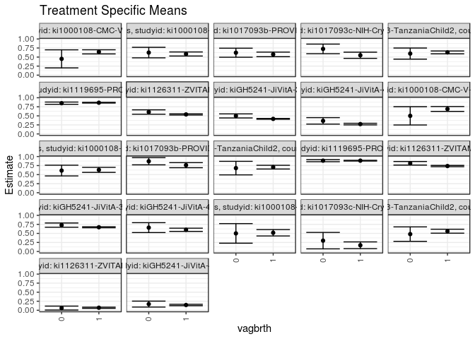

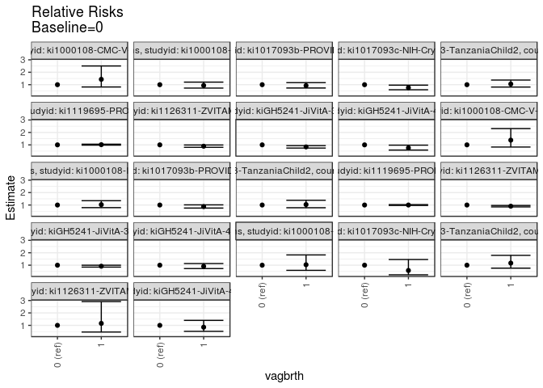

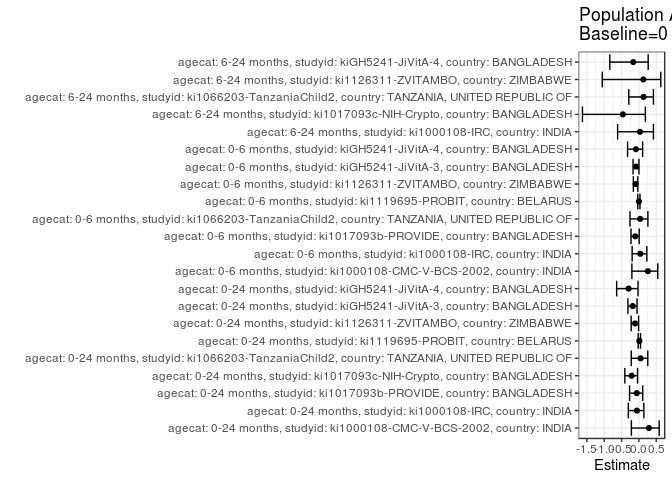

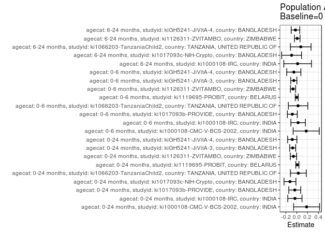

## Results Table

### Parameter: TSM

| agecat | studyid | country | intervention_level | baseline_level | estimate | ci_lower | ci_upper |
| --- | --- | --- | --- | --- | --- | --- | --- |
| 0-24 months | ki1000108-CMC-V-BCS-2002 | INDIA | 0 | NA | 0.4500000 | 0.2006580 | 0.6993420 |
| 0-24 months | ki1000108-CMC-V-BCS-2002 | INDIA | 1 | NA | 0.6437908 | 0.5870303 | 0.7005514 |
| 0-24 months | ki1000108-IRC | INDIA | 0 | NA | 0.6237765 | 0.4785117 | 0.7690412 |
| 0-24 months | ki1000108-IRC | INDIA | 1 | NA | 0.5851505 | 0.5290528 | 0.6412482 |
| 0-24 months | ki1017093b-PROVIDE | BANGLADESH | 0 | NA | 0.6201221 | 0.4949525 | 0.7452917 |
| 0-24 months | ki1017093b-PROVIDE | BANGLADESH | 1 | NA | 0.5735395 | 0.5100237 | 0.6370552 |
| 0-24 months | ki1017093c-NIH-Crypto | BANGLADESH | 0 | NA | 0.7254568 | 0.5930110 | 0.8579027 |
| 0-24 months | ki1017093c-NIH-Crypto | BANGLADESH | 1 | NA | 0.5495661 | 0.4640601 | 0.6350720 |
| 0-24 months | ki1066203-TanzaniaChild2 | TANZANIA, UNITED REPUBLIC OF | 0 | NA | 0.5960552 | 0.4425106 | 0.7495998 |
| 0-24 months | ki1066203-TanzaniaChild2 | TANZANIA, UNITED REPUBLIC OF | 1 | NA | 0.6285832 | 0.5893943 | 0.6677720 |
| 0-24 months | ki1119695-PROBIT | BELARUS | 0 | NA | 0.8496584 | 0.8183588 | 0.8809580 |
| 0-24 months | ki1119695-PROBIT | BELARUS | 1 | NA | 0.8630732 | 0.8524550 | 0.8736913 |
| 0-24 months | ki1126311-ZVITAMBO | ZIMBABWE | 0 | NA | 0.6053585 | 0.5449103 | 0.6658067 |
| 0-24 months | ki1126311-ZVITAMBO | ZIMBABWE | 1 | NA | 0.5394384 | 0.5221483 | 0.5567284 |
| 0-24 months | kiGH5241-JiVitA-3 | BANGLADESH | 0 | NA | 0.4981369 | 0.4417472 | 0.5545266 |
| 0-24 months | kiGH5241-JiVitA-3 | BANGLADESH | 1 | NA | 0.4158863 | 0.4044161 | 0.4273566 |
| 0-24 months | kiGH5241-JiVitA-4 | BANGLADESH | 0 | NA | 0.3608986 | 0.2717881 | 0.4500091 |
| 0-24 months | kiGH5241-JiVitA-4 | BANGLADESH | 1 | NA | 0.2718451 | 0.2498214 | 0.2938689 |
| 0-6 months | ki1000108-CMC-V-BCS-2002 | INDIA | 0 | NA | 0.5000000 | 0.2472620 | 0.7527380 |
| 0-6 months | ki1000108-CMC-V-BCS-2002 | INDIA | 1 | NA | 0.6898396 | 0.6225361 | 0.7571431 |
| 0-6 months | ki1000108-IRC | INDIA | 0 | NA | 0.6120636 | 0.4638744 | 0.7602529 |
| 0-6 months | ki1000108-IRC | INDIA | 1 | NA | 0.6315723 | 0.5620214 | 0.7011231 |
| 0-6 months | ki1017093b-PROVIDE | BANGLADESH | 0 | NA | 0.8695652 | 0.7703543 | 0.9687761 |
| 0-6 months | ki1017093b-PROVIDE | BANGLADESH | 1 | NA | 0.7608696 | 0.6908322 | 0.8309069 |
| 0-6 months | ki1066203-TanzaniaChild2 | TANZANIA, UNITED REPUBLIC OF | 0 | NA | 0.6800000 | 0.4929570 | 0.8670430 |
| 0-6 months | ki1066203-TanzaniaChild2 | TANZANIA, UNITED REPUBLIC OF | 1 | NA | 0.7064516 | 0.6550297 | 0.7578735 |
| 0-6 months | ki1119695-PROBIT | BELARUS | 0 | NA | 0.8856990 | 0.8566966 | 0.9147014 |
| 0-6 months | ki1119695-PROBIT | BELARUS | 1 | NA | 0.8860189 | 0.8758706 | 0.8961673 |
| 0-6 months | ki1126311-ZVITAMBO | ZIMBABWE | 0 | NA | 0.8134305 | 0.7640543 | 0.8628066 |
| 0-6 months | ki1126311-ZVITAMBO | ZIMBABWE | 1 | NA | 0.7368208 | 0.7188545 | 0.7547871 |
| 0-6 months | kiGH5241-JiVitA-3 | BANGLADESH | 0 | NA | 0.7295878 | 0.6711270 | 0.7880486 |
| 0-6 months | kiGH5241-JiVitA-3 | BANGLADESH | 1 | NA | 0.6705381 | 0.6566026 | 0.6844735 |
| 0-6 months | kiGH5241-JiVitA-4 | BANGLADESH | 0 | NA | 0.6596052 | 0.5229077 | 0.7963026 |
| 0-6 months | kiGH5241-JiVitA-4 | BANGLADESH | 1 | NA | 0.5996258 | 0.5547517 | 0.6445000 |
| 6-24 months | ki1000108-IRC | INDIA | 0 | NA | 0.5000000 | 0.2294903 | 0.7705097 |
| 6-24 months | ki1000108-IRC | INDIA | 1 | NA | 0.5179856 | 0.4297875 | 0.6061838 |
| 6-24 months | ki1017093c-NIH-Crypto | BANGLADESH | 0 | NA | 0.3000000 | 0.0725547 | 0.5274453 |
| 6-24 months | ki1017093c-NIH-Crypto | BANGLADESH | 1 | NA | 0.1724138 | 0.0793318 | 0.2654957 |
| 6-24 months | ki1066203-TanzaniaChild2 | TANZANIA, UNITED REPUBLIC OF | 0 | NA | 0.4802494 | 0.2802999 | 0.6801988 |
| 6-24 months | ki1066203-TanzaniaChild2 | TANZANIA, UNITED REPUBLIC OF | 1 | NA | 0.5611332 | 0.5065337 | 0.6157328 |
| 6-24 months | ki1126311-ZVITAMBO | ZIMBABWE | 0 | NA | 0.0609756 | 0.0065400 | 0.1154112 |
| 6-24 months | ki1126311-ZVITAMBO | ZIMBABWE | 1 | NA | 0.0706861 | 0.0547411 | 0.0866311 |
| 6-24 months | kiGH5241-JiVitA-4 | BANGLADESH | 0 | NA | 0.1713966 | 0.0894542 | 0.2533390 |
| 6-24 months | kiGH5241-JiVitA-4 | BANGLADESH | 1 | NA | 0.1460749 | 0.1263211 | 0.1658287 |

### Parameter: E(Y)

| agecat | studyid | country | intervention_level | baseline_level | estimate | ci_lower | ci_upper |
| --- | --- | --- | --- | --- | --- | --- | --- |
| 0-24 months | ki1000108-CMC-V-BCS-2002 | INDIA | NA | NA | 0.6319018 | 0.5759256 | 0.6878781 |
| 0-24 months | ki1000108-IRC | INDIA | NA | NA | 0.5898734 | 0.5376978 | 0.6420491 |
| 0-24 months | ki1017093b-PROVIDE | BANGLADESH | NA | NA | 0.5830619 | 0.5262762 | 0.6398476 |
| 0-24 months | ki1017093c-NIH-Crypto | BANGLADESH | NA | NA | 0.6000000 | 0.5288495 | 0.6711505 |
| 0-24 months | ki1066203-TanzaniaChild2 | TANZANIA, UNITED REPUBLIC OF | NA | NA | 0.6255319 | 0.5876598 | 0.6634040 |
| 0-24 months | ki1119695-PROBIT | BELARUS | NA | NA | 0.8612051 | 0.8511051 | 0.8713052 |
| 0-24 months | ki1126311-ZVITAMBO | ZIMBABWE | NA | NA | 0.5447361 | 0.5281997 | 0.5612725 |
| 0-24 months | kiGH5241-JiVitA-3 | BANGLADESH | NA | NA | 0.4227255 | 0.4115874 | 0.4338635 |
| 0-24 months | kiGH5241-JiVitA-4 | BANGLADESH | NA | NA | 0.2782123 | 0.2567662 | 0.2996583 |
| 0-6 months | ki1000108-CMC-V-BCS-2002 | INDIA | NA | NA | 0.6748768 | 0.6092233 | 0.7405304 |
| 0-6 months | ki1000108-IRC | INDIA | NA | NA | 0.6375000 | 0.5751450 | 0.6998550 |
| 0-6 months | ki1017093b-PROVIDE | BANGLADESH | NA | NA | 0.7880435 | 0.7295878 | 0.8464992 |
| 0-6 months | ki1066203-TanzaniaChild2 | TANZANIA, UNITED REPUBLIC OF | NA | NA | 0.7044776 | 0.6548846 | 0.7540707 |
| 0-6 months | ki1119695-PROBIT | BELARUS | NA | NA | 0.8855266 | 0.8758983 | 0.8951550 |
| 0-6 months | ki1126311-ZVITAMBO | ZIMBABWE | NA | NA | 0.7430972 | 0.7259776 | 0.7602169 |
| 0-6 months | kiGH5241-JiVitA-3 | BANGLADESH | NA | NA | 0.6752697 | 0.6619203 | 0.6886192 |
| 0-6 months | kiGH5241-JiVitA-4 | BANGLADESH | NA | NA | 0.6058824 | 0.5634305 | 0.6483342 |
| 6-24 months | ki1000108-IRC | INDIA | NA | NA | 0.5161290 | 0.4322562 | 0.6000019 |
| 6-24 months | ki1017093c-NIH-Crypto | BANGLADESH | NA | NA | 0.2051282 | 0.1132549 | 0.2970015 |
| 6-24 months | ki1066203-TanzaniaChild2 | TANZANIA, UNITED REPUBLIC OF | NA | NA | 0.5540541 | 0.5015831 | 0.6065250 |
| 6-24 months | ki1126311-ZVITAMBO | ZIMBABWE | NA | NA | 0.0699234 | 0.0546210 | 0.0852257 |
| 6-24 months | kiGH5241-JiVitA-4 | BANGLADESH | NA | NA | 0.1476563 | 0.1284384 | 0.1668741 |

### Parameter: RR

| agecat | studyid | country | intervention_level | baseline_level | estimate | ci_lower | ci_upper |
| --- | --- | --- | --- | --- | --- | --- | --- |
| 0-24 months | ki1000108-CMC-V-BCS-2002 | INDIA | 0 | 0 | 1.0000000 | 1.0000000 | 1.0000000 |
| 0-24 months | ki1000108-CMC-V-BCS-2002 | INDIA | 1 | 0 | 1.4306463 | 0.8163766 | 2.5071137 |
| 0-24 months | ki1000108-IRC | INDIA | 0 | 0 | 1.0000000 | 1.0000000 | 1.0000000 |
| 0-24 months | ki1000108-IRC | INDIA | 1 | 0 | 0.9380772 | 0.7292234 | 1.2067481 |
| 0-24 months | ki1017093b-PROVIDE | BANGLADESH | 0 | 0 | 1.0000000 | 1.0000000 | 1.0000000 |
| 0-24 months | ki1017093b-PROVIDE | BANGLADESH | 1 | 0 | 0.9248815 | 0.7339379 | 1.1655017 |
| 0-24 months | ki1017093c-NIH-Crypto | BANGLADESH | 0 | 0 | 1.0000000 | 1.0000000 | 1.0000000 |
| 0-24 months | ki1017093c-NIH-Crypto | BANGLADESH | 1 | 0 | 0.7575448 | 0.5948478 | 0.9647412 |
| 0-24 months | ki1066203-TanzaniaChild2 | TANZANIA, UNITED REPUBLIC OF | 0 | 0 | 1.0000000 | 1.0000000 | 1.0000000 |
| 0-24 months | ki1066203-TanzaniaChild2 | TANZANIA, UNITED REPUBLIC OF | 1 | 0 | 1.0545721 | 0.8091395 | 1.3744506 |
| 0-24 months | ki1119695-PROBIT | BELARUS | 0 | 0 | 1.0000000 | 1.0000000 | 1.0000000 |
| 0-24 months | ki1119695-PROBIT | BELARUS | 1 | 0 | 1.0157884 | 0.9772504 | 1.0558462 |
| 0-24 months | ki1126311-ZVITAMBO | ZIMBABWE | 0 | 0 | 1.0000000 | 1.0000000 | 1.0000000 |
| 0-24 months | ki1126311-ZVITAMBO | ZIMBABWE | 1 | 0 | 0.8911056 | 0.8026485 | 0.9893114 |
| 0-24 months | kiGH5241-JiVitA-3 | BANGLADESH | 0 | 0 | 1.0000000 | 1.0000000 | 1.0000000 |
| 0-24 months | kiGH5241-JiVitA-3 | BANGLADESH | 1 | 0 | 0.8348836 | 0.7430678 | 0.9380445 |
| 0-24 months | kiGH5241-JiVitA-4 | BANGLADESH | 0 | 0 | 1.0000000 | 1.0000000 | 1.0000000 |
| 0-24 months | kiGH5241-JiVitA-4 | BANGLADESH | 1 | 0 | 0.7532451 | 0.5808627 | 0.9767854 |
| 0-6 months | ki1000108-CMC-V-BCS-2002 | INDIA | 0 | 0 | 1.0000000 | 1.0000000 | 1.0000000 |
| 0-6 months | ki1000108-CMC-V-BCS-2002 | INDIA | 1 | 0 | 1.3796791 | 0.8245122 | 2.3086554 |
| 0-6 months | ki1000108-IRC | INDIA | 0 | 0 | 1.0000000 | 1.0000000 | 1.0000000 |
| 0-6 months | ki1000108-IRC | INDIA | 1 | 0 | 1.0318735 | 0.7901321 | 1.3475760 |
| 0-6 months | ki1017093b-PROVIDE | BANGLADESH | 0 | 0 | 1.0000000 | 1.0000000 | 1.0000000 |
| 0-6 months | ki1017093b-PROVIDE | BANGLADESH | 1 | 0 | 0.8750000 | 0.7556881 | 1.0131495 |
| 0-6 months | ki1066203-TanzaniaChild2 | TANZANIA, UNITED REPUBLIC OF | 0 | 0 | 1.0000000 | 1.0000000 | 1.0000000 |
| 0-6 months | ki1066203-TanzaniaChild2 | TANZANIA, UNITED REPUBLIC OF | 1 | 0 | 1.0388994 | 0.7816335 | 1.3808416 |
| 0-6 months | ki1119695-PROBIT | BELARUS | 0 | 0 | 1.0000000 | 1.0000000 | 1.0000000 |
| 0-6 months | ki1119695-PROBIT | BELARUS | 1 | 0 | 1.0003612 | 0.9663852 | 1.0355318 |
| 0-6 months | ki1126311-ZVITAMBO | ZIMBABWE | 0 | 0 | 1.0000000 | 1.0000000 | 1.0000000 |
| 0-6 months | ki1126311-ZVITAMBO | ZIMBABWE | 1 | 0 | 0.9058190 | 0.8494063 | 0.9659784 |
| 0-6 months | kiGH5241-JiVitA-3 | BANGLADESH | 0 | 0 | 1.0000000 | 1.0000000 | 1.0000000 |
| 0-6 months | kiGH5241-JiVitA-3 | BANGLADESH | 1 | 0 | 0.9190642 | 0.8460472 | 0.9983830 |
| 0-6 months | kiGH5241-JiVitA-4 | BANGLADESH | 0 | 0 | 1.0000000 | 1.0000000 | 1.0000000 |
| 0-6 months | kiGH5241-JiVitA-4 | BANGLADESH | 1 | 0 | 0.9090679 | 0.7291627 | 1.1333606 |
| 6-24 months | ki1000108-IRC | INDIA | 0 | 0 | 1.0000000 | 1.0000000 | 1.0000000 |
| 6-24 months | ki1000108-IRC | INDIA | 1 | 0 | 1.0359712 | 0.5874383 | 1.8269773 |
| 6-24 months | ki1017093c-NIH-Crypto | BANGLADESH | 0 | 0 | 1.0000000 | 1.0000000 | 1.0000000 |
| 6-24 months | ki1017093c-NIH-Crypto | BANGLADESH | 1 | 0 | 0.5747126 | 0.2266054 | 1.4575764 |
| 6-24 months | ki1066203-TanzaniaChild2 | TANZANIA, UNITED REPUBLIC OF | 0 | 0 | 1.0000000 | 1.0000000 | 1.0000000 |
| 6-24 months | ki1066203-TanzaniaChild2 | TANZANIA, UNITED REPUBLIC OF | 1 | 0 | 1.1684206 | 0.7626756 | 1.7900227 |
| 6-24 months | ki1126311-ZVITAMBO | ZIMBABWE | 0 | 0 | 1.0000000 | 1.0000000 | 1.0000000 |
| 6-24 months | ki1126311-ZVITAMBO | ZIMBABWE | 1 | 0 | 1.1592516 | 0.4616155 | 2.9112199 |
| 6-24 months | kiGH5241-JiVitA-4 | BANGLADESH | 0 | 0 | 1.0000000 | 1.0000000 | 1.0000000 |
| 6-24 months | kiGH5241-JiVitA-4 | BANGLADESH | 1 | 0 | 0.8522625 | 0.5185127 | 1.4008362 |

### Parameter: PAR

| agecat | studyid | country | intervention_level | baseline_level | estimate | ci_lower | ci_upper |
| --- | --- | --- | --- | --- | --- | --- | --- |
| 0-24 months | ki1000108-CMC-V-BCS-2002 | INDIA | 0 | NA | 0.1819018 | -0.0576922 | 0.4214959 |
| 0-24 months | ki1000108-IRC | INDIA | 0 | NA | -0.0339031 | -0.1653931 | 0.0975870 |
| 0-24 months | ki1017093b-PROVIDE | BANGLADESH | 0 | NA | -0.0370602 | -0.1470251 | 0.0729047 |
| 0-24 months | ki1017093c-NIH-Crypto | BANGLADESH | 0 | NA | -0.1254568 | -0.2344518 | -0.0164619 |
| 0-24 months | ki1066203-TanzaniaChild2 | TANZANIA, UNITED REPUBLIC OF | 0 | NA | 0.0294767 | -0.1174641 | 0.1764176 |
| 0-24 months | ki1119695-PROBIT | BELARUS | 0 | NA | 0.0115467 | -0.0180528 | 0.0411463 |
| 0-24 months | ki1126311-ZVITAMBO | ZIMBABWE | 0 | NA | -0.0606224 | -0.1187389 | -0.0025059 |
| 0-24 months | kiGH5241-JiVitA-3 | BANGLADESH | 0 | NA | -0.0754115 | -0.1305737 | -0.0202492 |
| 0-24 months | kiGH5241-JiVitA-4 | BANGLADESH | 0 | NA | -0.0826864 | -0.1678117 | 0.0024390 |
| 0-6 months | ki1000108-CMC-V-BCS-2002 | INDIA | 0 | NA | 0.1748768 | -0.0657175 | 0.4154712 |
| 0-6 months | ki1000108-IRC | INDIA | 0 | NA | 0.0254364 | -0.1086250 | 0.1594978 |
| 0-6 months | ki1017093b-PROVIDE | BANGLADESH | 0 | NA | -0.0815217 | -0.1728369 | 0.0097935 |
| 0-6 months | ki1066203-TanzaniaChild2 | TANZANIA, UNITED REPUBLIC OF | 0 | NA | 0.0244776 | -0.1550298 | 0.2039850 |
| 0-6 months | ki1119695-PROBIT | BELARUS | 0 | NA | -0.0001724 | -0.0276785 | 0.0273338 |
| 0-6 months | ki1126311-ZVITAMBO | ZIMBABWE | 0 | NA | -0.0703332 | -0.1177700 | -0.0228965 |
| 0-6 months | kiGH5241-JiVitA-3 | BANGLADESH | 0 | NA | -0.0543181 | -0.1115680 | 0.0029318 |
| 0-6 months | kiGH5241-JiVitA-4 | BANGLADESH | 0 | NA | -0.0537228 | -0.1843003 | 0.0768547 |
| 6-24 months | ki1000108-IRC | INDIA | 0 | NA | 0.0161290 | -0.2390237 | 0.2712818 |
| 6-24 months | ki1017093c-NIH-Crypto | BANGLADESH | 0 | NA | -0.0948718 | -0.2780930 | 0.0883494 |
| 6-24 months | ki1066203-TanzaniaChild2 | TANZANIA, UNITED REPUBLIC OF | 0 | NA | 0.0738047 | -0.1173515 | 0.2649609 |
| 6-24 months | ki1126311-ZVITAMBO | ZIMBABWE | 0 | NA | 0.0089478 | -0.0433206 | 0.0612162 |
| 6-24 months | kiGH5241-JiVitA-4 | BANGLADESH | 0 | NA | -0.0237403 | -0.1026489 | 0.0551682 |

### Parameter: PAF

| agecat | studyid | country | intervention_level | baseline_level | estimate | ci_lower | ci_upper |
| --- | --- | --- | --- | --- | --- | --- | --- |
| 0-24 months | ki1000108-CMC-V-BCS-2002 | INDIA | 0 | NA | 0.2878641 | -0.2169136 | 0.5832592 |
| 0-24 months | ki1000108-IRC | INDIA | 0 | NA | -0.0574751 | -0.3051964 | 0.1432296 |
| 0-24 months | ki1017093b-PROVIDE | BANGLADESH | 0 | NA | -0.0635614 | -0.2698300 | 0.1092014 |
| 0-24 months | ki1017093c-NIH-Crypto | BANGLADESH | 0 | NA | -0.2090947 | -0.4059605 | -0.0397946 |
| 0-24 months | ki1066203-TanzaniaChild2 | TANZANIA, UNITED REPUBLIC OF | 0 | NA | 0.0471227 | -0.2194736 | 0.2554367 |
| 0-24 months | ki1119695-PROBIT | BELARUS | 0 | NA | 0.0134077 | -0.0215688 | 0.0471866 |
| 0-24 months | ki1126311-ZVITAMBO | ZIMBABWE | 0 | NA | -0.1112877 | -0.2233173 | -0.0095176 |
| 0-24 months | kiGH5241-JiVitA-3 | BANGLADESH | 0 | NA | -0.1783935 | -0.3164243 | -0.0548355 |
| 0-24 months | kiGH5241-JiVitA-4 | BANGLADESH | 0 | NA | -0.2972060 | -0.6414995 | -0.0251257 |
| 0-6 months | ki1000108-CMC-V-BCS-2002 | INDIA | 0 | NA | 0.2591241 | -0.2023404 | 0.5434761 |
| 0-6 months | ki1000108-IRC | INDIA | 0 | NA | 0.0399002 | -0.1952742 | 0.2288032 |
| 0-6 months | ki1017093b-PROVIDE | BANGLADESH | 0 | NA | -0.1034483 | -0.2274251 | 0.0080062 |
| 0-6 months | ki1066203-TanzaniaChild2 | TANZANIA, UNITED REPUBLIC OF | 0 | NA | 0.0347458 | -0.2569309 | 0.2587375 |
| 0-6 months | ki1119695-PROBIT | BELARUS | 0 | NA | -0.0001946 | -0.0317440 | 0.0303900 |
| 0-6 months | ki1126311-ZVITAMBO | ZIMBABWE | 0 | NA | -0.0946488 | -0.1605725 | -0.0324697 |
| 0-6 months | kiGH5241-JiVitA-3 | BANGLADESH | 0 | NA | -0.0804391 | -0.1686939 | 0.0011511 |
| 0-6 months | kiGH5241-JiVitA-4 | BANGLADESH | 0 | NA | -0.0886687 | -0.3272201 | 0.1070060 |
| 6-24 months | ki1000108-IRC | INDIA | 0 | NA | 0.0312500 | -0.6139924 | 0.4185372 |
| 6-24 months | ki1017093c-NIH-Crypto | BANGLADESH | 0 | NA | -0.4625000 | -1.6271554 | 0.1858471 |
| 6-24 months | ki1066203-TanzaniaChild2 | TANZANIA, UNITED REPUBLIC OF | 0 | NA | 0.1332085 | -0.2915481 | 0.4182737 |
| 6-24 months | ki1126311-ZVITAMBO | ZIMBABWE | 0 | NA | 0.1279653 | -1.0561158 | 0.6301548 |
| 6-24 months | kiGH5241-JiVitA-4 | BANGLADESH | 0 | NA | -0.1607812 | -0.8388247 | 0.2672423 |